# STA141A Final project

Bohan Chen

2025-02-09

# 1. Abstract

# 2. Introduction

### 1.Questions of Interest: The project aims to understand the decision-making behavior of mice in response to visual stimuli, specifically focusing on the impact of contrast levels on success rates and neural activity.

### 2.Impact of Results: The findings could provide insights into neural mechanisms underlying decision-making and potential biases in animal behavior.

### 3.Real-World Motivation: Understanding these mechanisms can contribute to neuroscience research and potentially inform models of human decision-making.

### 4.Problem Setup: The problem involves analyzing neural data from mice performing a visual decision task, with data sourced from multiple sessions.

### 5.Key Variables: Feedback type (success/failure), contrast levels (left and right), neural firing rates, and brain areas. 6.Hypotheses: Mice may show decision biases based on contrast levels, and neural activity may correlate with success rates.

# 3. Background

### 1.Source of Data: Neural data from mice performing a visual decision task.

### 2.Target Population: Mice used in neuroscience experiments.

### 3.Sampling Mechanism: Data collected across 18 sessions, each with multiple trials.

### 4.Explanation of Variables: Feedback type, contrast levels, neural firing rates, and brain areas are explained.

### 5.Relevant Research: The project builds on existing neuroscience research on decision-making and neural activity.

# 4 Exploratory analysis

## 4.1 Count the number of trials, neurons, and brain areas for each session, which let the results are stored in a data frame for easy viewing.

```
##    Session Trials Neurons Brain_Areas
## 1        1    114     734           8
## 2        2    251    1070           5
## 3        3    228     619          11
## 4        4    249    1769          11
## 5        5    254    1077          10
## 6        6    290    1169           5
## 7        7    252     584           8
## 8        8    250    1157          15
## 9        9    372     788          12
## 10      10    447    1172          13
## 11      11    342     857           6
## 12      12    340     698          12
## 13      13    300     983          15
## 14      14    268     756          10
## 15      15    404     743           8
## 16      16    280     474           6
## 17      17    224     565           6
## 18      18    216    1090          10
```

### 1. Trial Counts Across Sessions

2.Later Sessions (11–18): Trial counts drop after Session 10, fluctuating between 216 (Session 18) and 404 (Session 15). The drop in later sessions might indicate task modifications, experimental adjustments, or cognitive fatigue in subjects. Sessions 15 and 11 have relatively higher trial counts, indicating possible secondary peaks in engagement.

### 2. Neuron Counts Across Sessions

1.High Neuron Count Sessions: Session 4 (1769 neurons) recorded the highest number of neurons, possibly due to specific experimental conditions. Sessions 6, 10, and 18 also have high neuron counts, suggesting key experimental milestones.

2.Low Neuron Count Sessions: Session 16 has the lowest neuron count (474), followed by Sessions 7 and 17. A general decline in neuron count is observed after Session 10, potentially reflecting changes in task complexity, experimental setup, or adaptation.

### 3. Brain Areas Across Sessions

1.Most Diverse Brain Activity: Session 8 and 13 recorded the highest number of brain areas (15), providing a broader representation of neural activity. Sessions 9, 10, 12, and 14 also have a relatively high number of brain areas.

### Summarize the distribution of feedback_type, contrast_left, and contrast_right across sessions

```
## [1] "Feedback Type Distribution:"
```

```
##  -1   1  -1   1  -1   1  -1   1  -1   1  -1   1  -1   1  -1   1  -1   1  -1   1
##  45  69  92 159  77 151  83 166  86 168  75 215  83 169  89 161 117 255 170 277
##  -1   1  -1   1  -1   1  -1   1  -1   1  -1   1  -1   1  -1   1
##  70 272  89 251  61 239  82 186  95 309  79 201  38 186  42 174
```

```
## [1] "Left Contrast Distribution:"
```

```
##    0 0.25  0.5    1    0 0.25  0.5    1    0 0.25  0.5    1    0 0.25  0.5    1
##   51   27   18   18  133   25   39   54  137   31   28   32  112   41   46   50
##    0 0.25  0.5    1    0 0.25  0.5    1    0 0.25  0.5    1    0 0.25  0.5    1
##  112   46   43   53  122   52   53   63  120   46   47   39   94   40   31   85
##    0 0.25  0.5    1    0 0.25  0.5    1    0 0.25  0.5    1    0 0.25  0.5    1
##  153   45   68  106  193   60   74  120  159   50   62   71  173   55   55   57
##    0 0.25  0.5    1    0 0.25  0.5    1    0 0.25  0.5    1    0 0.25  0.5    1
##  135   43   52   70  130   38   41   59  191   56   68   89  124   42   43   71
##    0 0.25  0.5    1    0 0.25  0.5    1
##  103   41   35   45  103   36   34   43
```

```
## [1] "Right Contrast Distribution:"
```

```
##    0 0.25  0.5    1    0 0.25  0.5    1    0 0.25  0.5    1    0 0.25  0.5    1
##   43   14   23   34  115   41   34   61  109   26   31   62  107   55   41   46
##    0 0.25  0.5    1    0 0.25  0.5    1    0 0.25  0.5    1    0 0.25  0.5    1
##  105   48   45   56  125   59   53   53  119   38   45   50  102   47   38   63
##    0 0.25  0.5    1    0 0.25  0.5    1    0 0.25  0.5    1    0 0.25  0.5    1
##  193   74   48   57  245   73   53   76  173   47   53   69  167   50   50   73
##    0 0.25  0.5    1    0 0.25  0.5    1    0 0.25  0.5    1    0 0.25  0.5    1
##  138   64   45   53  128   44   50   46  189   67   59   89  127   64   38   51
##    0 0.25  0.5    1    0 0.25  0.5    1
##   90   39   36   59  110   32   33   41
```

## 4.2 Visualize the distribution of contrast_left and contrast_right

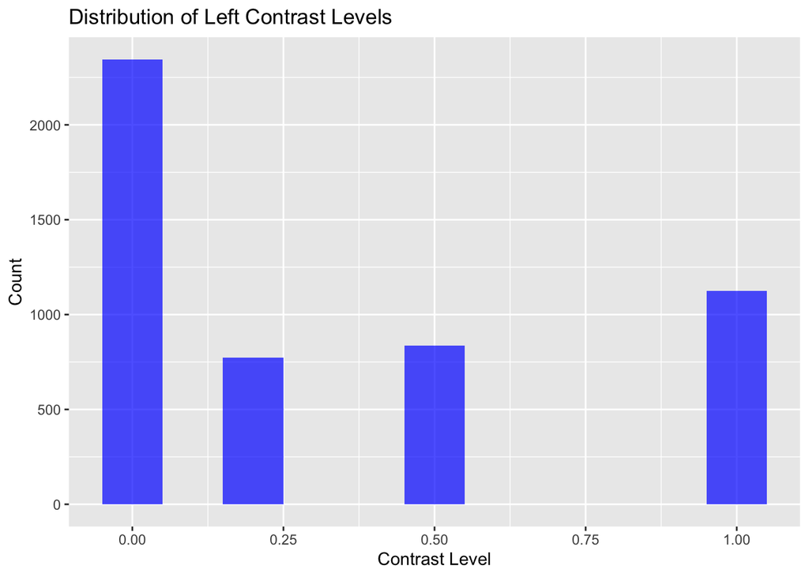

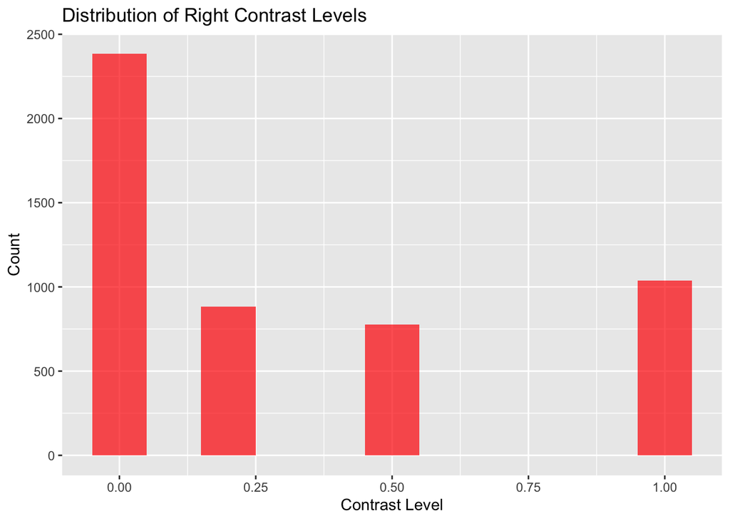

### 1. Uneven Contrast Distributions

2. There is a noticeable drop at contrast = 0.25, followed by a slight increase at contrast = 0.5 and contrast = 1.0, suggesting a non-uniform trial design. Left vs. Right Contrast Are Similar but Not Identical.
3. The overall shape of the left contrast and right contrast distributions appear similar. However, small differences in bar heights suggest that one side might have been slightly more biased toward certain contrast levels in some sessions. This could impact mouse decision-making behavior, as slight imbalances might introduce side preferences.

## 4.3 Success rate for each contrast level combination among different mice

```
##    contrast_left contrast_right mouse_name success_rate
## 1           0.00           0.00       Cori    0.6626506
## 2           0.00           0.25       Cori    0.6000000
## 3           0.00           0.50       Cori    0.7600000
## 4           0.00           1.00       Cori    0.5176471
## 5           0.25           0.00       Cori    0.7777778
## 6           0.25           0.25       Cori    0.5882353
## 7           0.25           0.50       Cori    0.4615385
## 8           0.25           1.00       Cori    0.5000000
## 9           0.50           0.00       Cori    0.7142857
## 10          0.50           0.25       Cori    0.8000000
## 11          0.50           0.50       Cori    0.4000000
## 12          0.50           1.00       Cori    0.7272727
## 13          1.00           0.00       Cori    0.9069767
## 14          1.00           0.25       Cori    0.6176471
```

[output cut: 50 more lines]

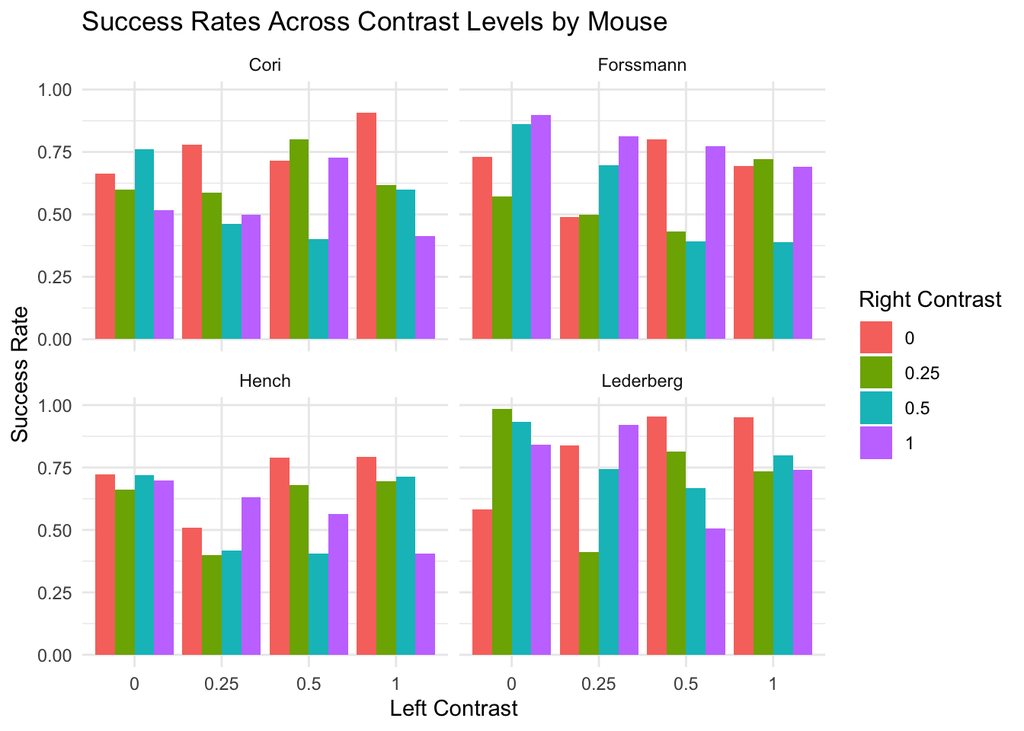

### 1. Contrast Difference Matters

```
1.Success rates tend to be higher when the contrast difference between the left and right sides is large (e.g., left = 1, right = 0).

2.Success rates drop when the contrast is more balanced (e.g., left = 0.25, right = 0.25).

3.This aligns with the idea that mice find it easier to make decisions when the stimulus difference is strong.
```

### 2. Individual Mouse Variability

```
1.Cori & Hench show relatively consistent performance across conditions but have noticeable drops at certain contrast levels.

2.Forssmann has a significant success rate boost when right contrast is 1, suggesting a potential right-side bias.

3.Lederberg has the highest success rates when the left contrast is 0 and the right contrast is 0.25 or 0.5, indicating that lower left contrast might be beneficial for this mouse.
```

### 3. Effect of Right Contrast

```
1.When right contrast is 0, success rates tend to be high, especially for Forssmann and Hench.

2.When right contrast is 1, success rates drop for some conditions, showing that mice might struggle with extreme right contrast.

3.Potential Biases
Some mice, such as Forssmann, seem to perform better when the right contrast is high, potentially indicating a side preference.
Lederberg shows a different pattern, where certain left contrast values (like 1) seem to boost performance regardless of the right contrast.
```

## 4.4 Test for decision biases in ambiguous contrast conditions (e.g., when left contrast ≈ right contrast), we will: Filter trials where left contrast ≈ right contrast (e.g., both 0, both 0.25, both 0.5, both 1).

```
## # A tibble: 32 × 7
##    mouse_name contrast_left contrast_right feedback_type choice_count
##    <chr>              <dbl>          <dbl>         <dbl>        <int>
##  1 Cori                0              0               -1           56
##  2 Cori                0              0                1          110
##  3 Cori                0.25           0.25            -1            7
##  4 Cori                0.25           0.25             1           10
##  5 Cori                0.5            0.5             -1            9
##  6 Cori                0.5            0.5              1            6
##  7 Cori                1              1               -1           10
##  8 Cori                1              1                1            7
##  9 Forssmann           0              0               -1           83
## 10 Forssmann           0              0                1          224
## # ℹ 22 more rows
## # ℹ 2 more variables: choice_direction <chr>, proportion <dbl>
```

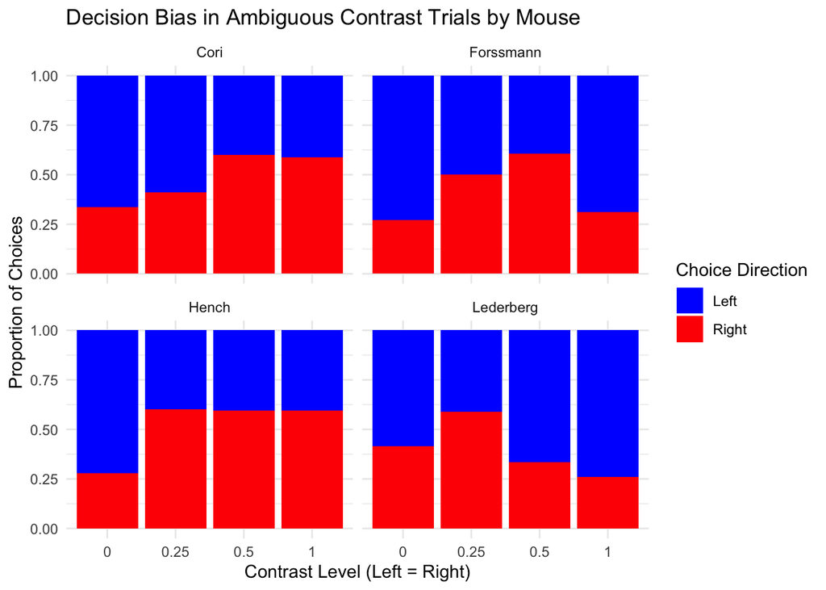

### 1. Mouse-Specific Biases:

[output not shown]

## 4.5 Based on 4.4, Explore whether the bias of each mouse will have a clear tendency as the session increases

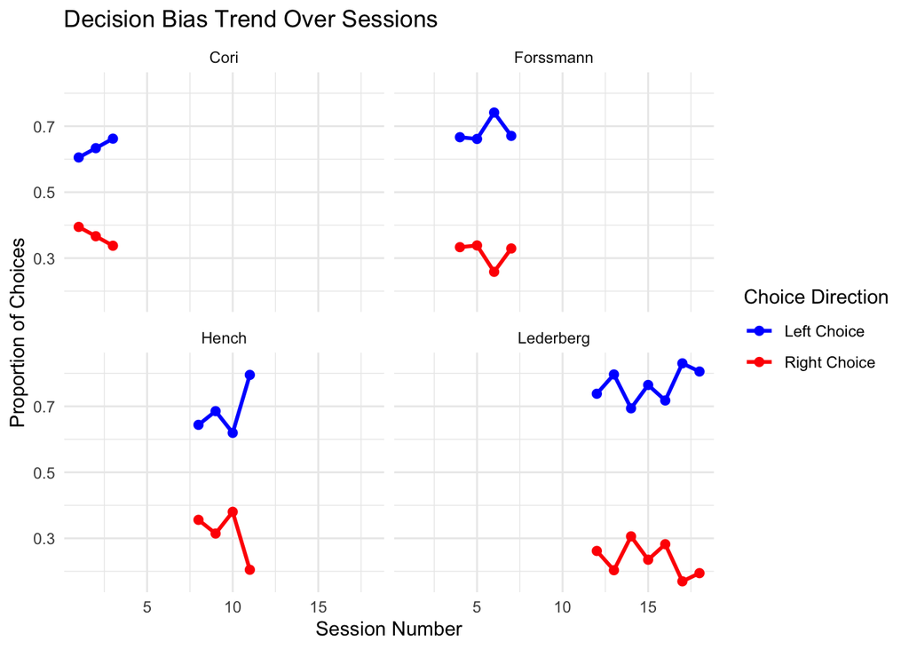

### 1. Findings from the Decision Bias Trend Over Sessions

[output not shown]

### 2. Stable Bias in Some Mice:

```
1.Forssmann's bias remains relatively stable, indicating that their decision-making is consistent across sessions.

2.Cori shows a slight increase in left choices, but it's not as strong as Hench or Lederberg.
```

### 3. Fluctuating Bias in Some Cases:

```
In Hench, there is some fluctuation in left choice preference, but the overall trend is increasing.This could indicate that decision-making is adaptive and may depend on specific conditions in each session.
```

## 4.6 Explore Distribution of Absolute Contrast Difference Across All Sessions

```
##   mouse_name abs_contrast_diff
## 1       Cori               0.5
## 2       Cori               0.0
## 3       Cori               0.5
## 4       Cori               0.0
## 5       Cori               0.0
## 6       Cori               0.0
```

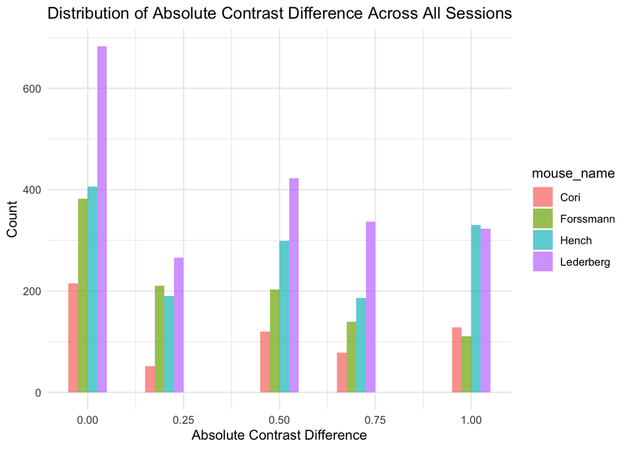

### 1. High Frequency of Trials with Zero Contrast Difference

[output not shown]

### 2. Uneven Distribution of Contrast Differences

[output not shown]

### 3. Mouse-Specific Differences in Trial Distribution

[output not shown]

### 4. Potential Bias in Trial Design

[output not shown]

## 4.7 Explore Mouse Decision Bias Across Absolute Contrast Differences,To Find Any Rules Between Chioce Decision And Absolute Contrast Differences

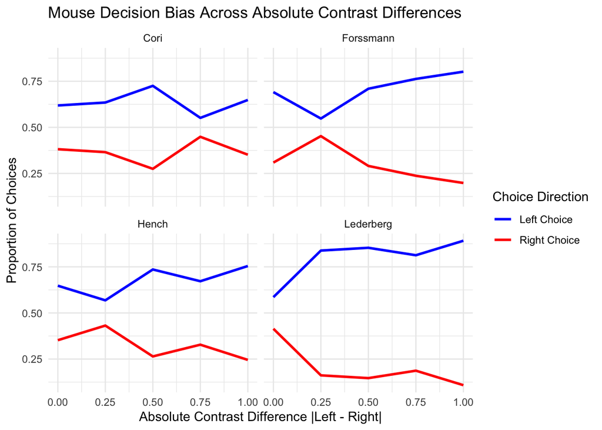

### 1. Bias at abs(contrast_left - contrast_right) = 0

```
Some mice do not choose 50-50 when the contrast is equal.
If a mouse prefers left more often at abs_contrast_diff = 0, it suggests a natural left-side bias independent of contrast.
Forssmann and Hench show a stronger left-choice tendency in ambiguous cases.
Increasing Absolute Contrast Difference
```

### 2. As abs_contrast_diff increases:

```
Left choices increase (for most mice).
Right choices decrease, indicating that mice rely more on contrast to make decisions.
The trend isn't perfectly linear, suggesting that individual biases interact with contrast strength.
```

### 3. Mouse-Specific Trends

```
Lederberg has a strong left bias at medium contrast differences but flattens out at high values.
Hench appears more random at mid-range contrast differences, meaning decisions may not be fully driven by contrast.
Forssmann's left-choice rate stabilizes over higher contrast differences, indicating clearer decision-making with stronger stimuli.
```

## All The Contrast Level Were Done And For Futher Investigation, Neural Activity Is Also An Important Part For Influence The Mouse Decision

## 4.8 Neural Activities - Average Spike Rate per Neuron

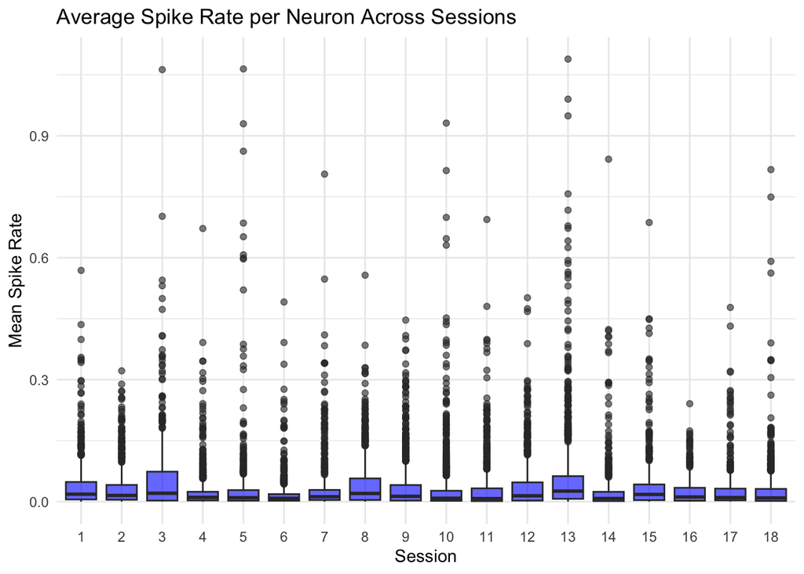

### 1. Low Mean Firing Rates Across Sessions:

```
The majority of neurons exhibit relatively low spike rates, with the median values clustered close to zero.
This suggests that most neurons fire infrequently during trials.
```

### 2. Presence of Outliers:

[output not shown]

### 3. Session-to-Session Variability:

Some sessions (e.g., Session 3, Session 13) appear to have slightly higher median spike rates and more variance compared to other sessions. This could indicate variability in neural engagement or differences in task conditions across sessions.

### 4. Heterogeneity in Neural Activity:

The spread of firing rates varies across sessions, indicating that some sessions have more heterogeneous neuronal responses than others.

## 4.9 Changes Across Trials - Success Rate

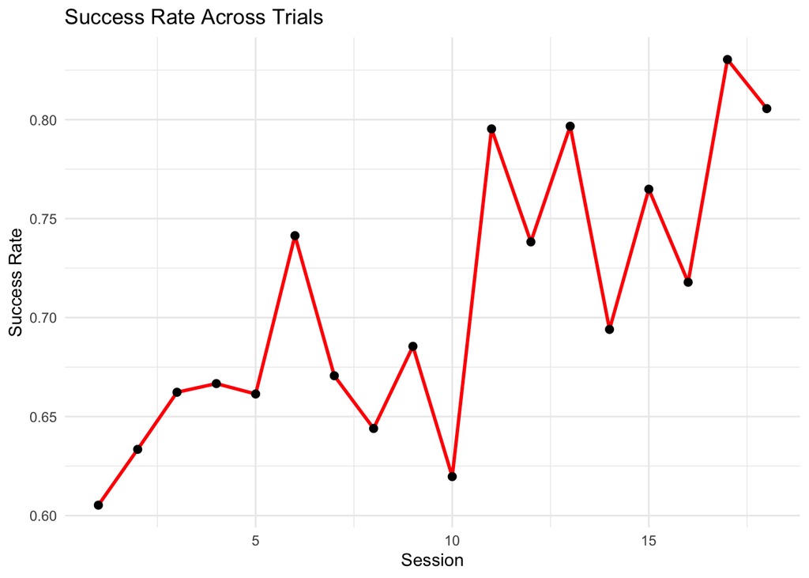

### 1. Overall Increasing Trend:

[output not shown]

### 2. Fluctuations in Performance:

```
Although there is a general upward trend, success rates show noticeable fluctuations, with some sessions experiencing sharp drops.
For example, around Session 10, there is a sharp dip, suggesting possible difficulty in that session’s task conditions or a temporary performance decline.
```

### 3. Plateauing Effect Toward the End:

[output not shown]

### 4. Potential Experiment Effects:

```
The sharp increase after Session 10 suggests that something may have changed in the experiment—possibly new training, reinforcement, or an adjustment in trial difficulty.
Checking for external changes in task structure or reward mechanisms could help explain these shifts.
```

## 4.10 Homogeneity & Heterogeneity Across Sessions & Mice

```
##        Mouse Session Neurons Trials Brain_Areas
## 1       Cori       1     734    114           8
## 2       Cori       2    1070    251           5
## 3       Cori       3     619    228          11
## 4  Forssmann       4    1769    249          11
## 5  Forssmann       5    1077    254          10
## 6  Forssmann       6    1169    290           5
## 7  Forssmann       7     584    252           8
## 8      Hench       8    1157    250          15
## 9      Hench       9     788    372          12
## 10     Hench      10    1172    447          13
## 11     Hench      11     857    342           6
## 12 Lederberg      12     698    340          12
## 13 Lederberg      13     983    300          15
## 14 Lederberg      14     756    268          10
## 15 Lederberg      15     743    404           8
## 16 Lederberg      16     474    280           6
## 17 Lederberg      17     565    224           6
## 18 Lederberg      18    1090    216          10
```

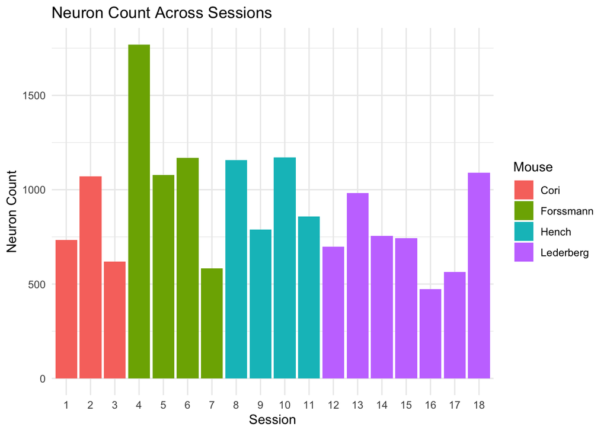

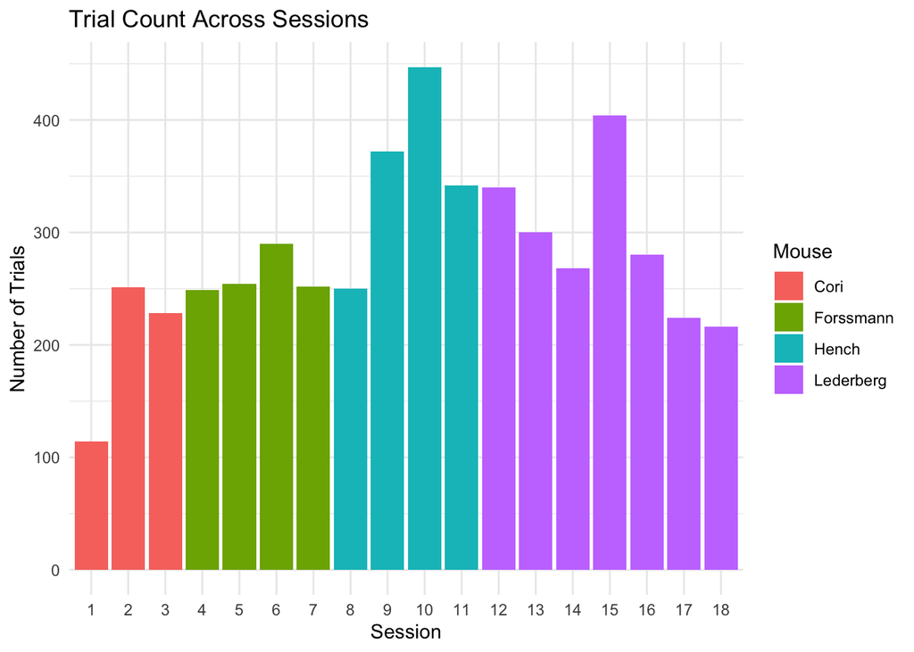

[output not shown]

## 4.11 Compare High vs. Low Firing Rate Neurons Across Brain Areas ###This identifies whether neurons with higher firing rates are concentrated in certain brain areas or randomly distributed.

[figure not shown]

### 1. Uneven Distribution of High-Firing Neurons

```
Certain brain areas have a significantly higher concentration of high-firing rate neurons compared to others.
One particular brain area shows an exceptionally high spike rate, suggesting it may play a key role in task-related neural activity.
```

## 4.12 Compare Firing Rates in Success vs. Failure Trials

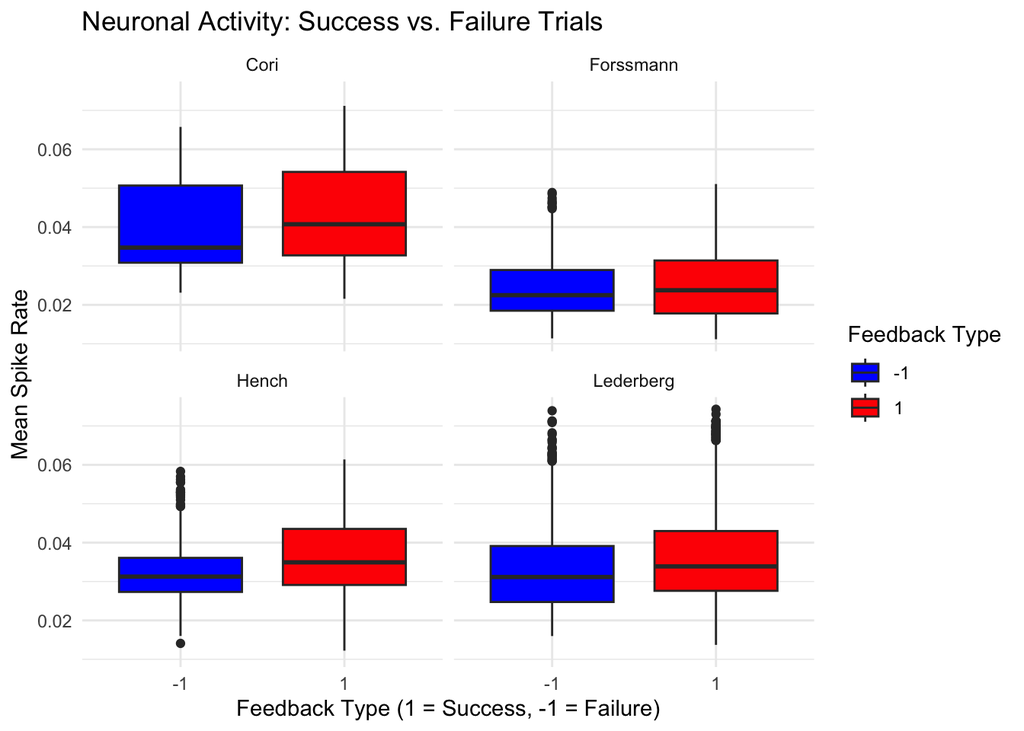

```
## # A tibble: 4 × 2
##   mouse_name t_test_p
##   <chr>         <dbl>
## 1 Cori       1.72e- 4
## 2 Forssmann  6.42e- 2
## 3 Hench      1.65e-14
## 4 Lederberg  1.19e- 6
```

### 1. Session 8 and Session 13 recorded the highest number of brain areas (15).

```
This means that during these sessions, neural activity was recorded from many different regions of the brain.
These sessions likely involved a more complex experiment, requiring broader neural monitoring.
```

```
These sessions may have been focused on specific brain regions, rather than collecting data from multiple areas.
```

### 3. Overall trend:

```
The number of recorded brain areas fluctuates throughout the sessions.
There is no clear increasing or decreasing trend.
```

## 4.13 Correlate Firing Rates with Absolute Contrast Difference

```
##   mouse_name abs_contrast_diff feedback_type
## 1       Cori               0.5             1
## 2       Cori               0.0             1
## 3       Cori               0.5            -1
## 4       Cori               0.0            -1
## 5       Cori               0.0            -1
## 6       Cori               0.0             1
```

[figure not shown]

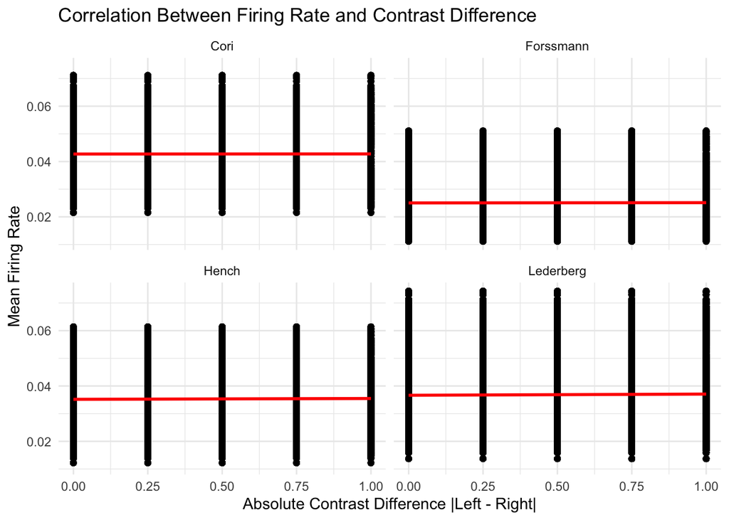

```
## # A tibble: 4 × 2
##   mouse_name correlation
##   <chr>            <dbl>
## 1 Cori           0.00122
## 2 Forssmann      0.00331
## 3 Hench          0.0118
## 4 Lederberg      0.0121
```

The firing rates appear to be clustered around similar values regardless of contrast difference.

There is no strong trend that firing rates increase or decrease as contrast difference changes.

## 4.14 Early vs. Late Firing Rate and Success

```
## Correlation between early firing rate and success: 0.06079061
```

```
## Correlation between late firing rate and success: 0.1538657
```

```
##
## Call:
## glm(formula = success ~ early_firing_rate + late_firing_rate,
##     family = "binomial", data = firing_success_df)
##
## Coefficients:
##                    Estimate Std. Error z value Pr(>|z|)
## (Intercept)         0.18183    0.09287   1.958   0.0502 .
## early_firing_rate -59.99614    5.72187 -10.485   <2e-16 ***
## late_firing_rate   76.58964    5.51450  13.889   <2e-16 ***
## ---
## Signif. codes:  0 '***' 0.001 '**' 0.01 '*' 0.05 '.' 0.1 ' ' 1
##
## (Dispersion parameter for binomial family taken to be 1)
##
##     Null deviance: 6118.2  on 5080  degrees of freedom
## Residual deviance: 5875.4  on 5078  degrees of freedom
## AIC: 5881.4
##
## Number of Fisher Scoring iterations: 4
```

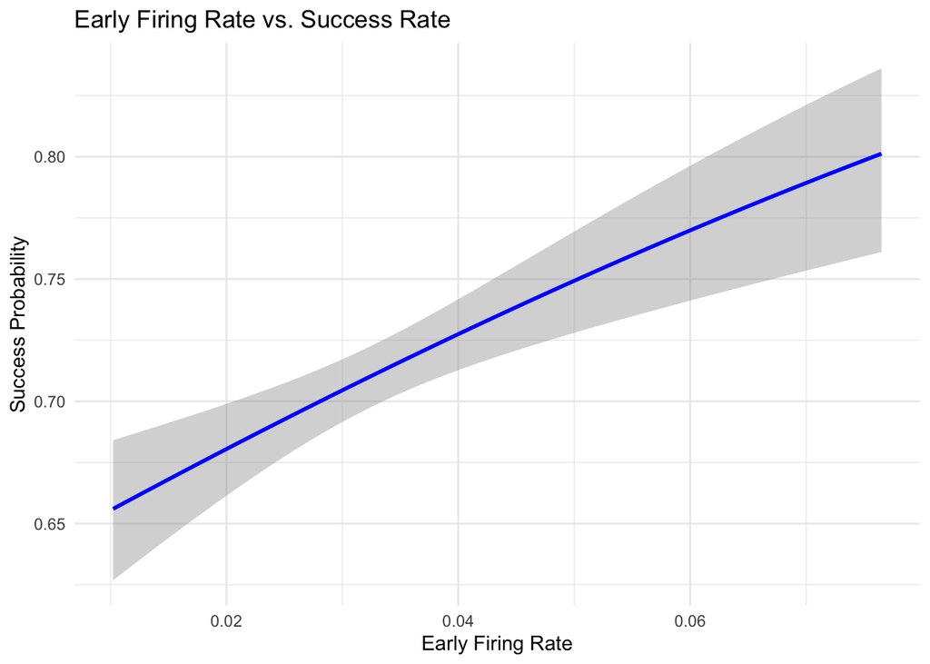

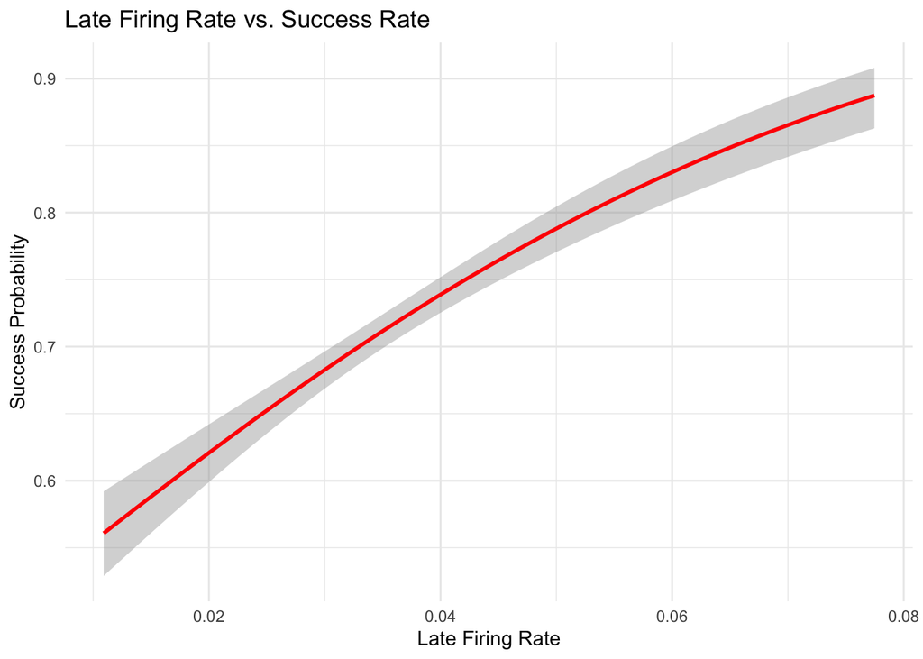

### 1. Early Firing Rate and Success Probability:

```
Higher early firing rates correlate with increased success probability.
```

This suggests that early neural activity could play a role in encoding or predicting successful decisions.

### 2. Late Firing Rate and Success Probability:

A stronger positive correlation than early firing rate. This may indicate that late-stage neural activity reflects commitment to a decision or confidence in the choice.

## 4.15 Influence of early and late firing rates on success probability for each mouse

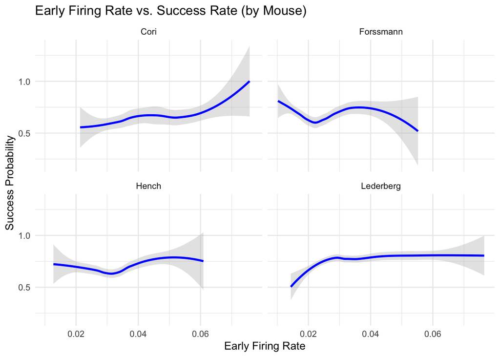

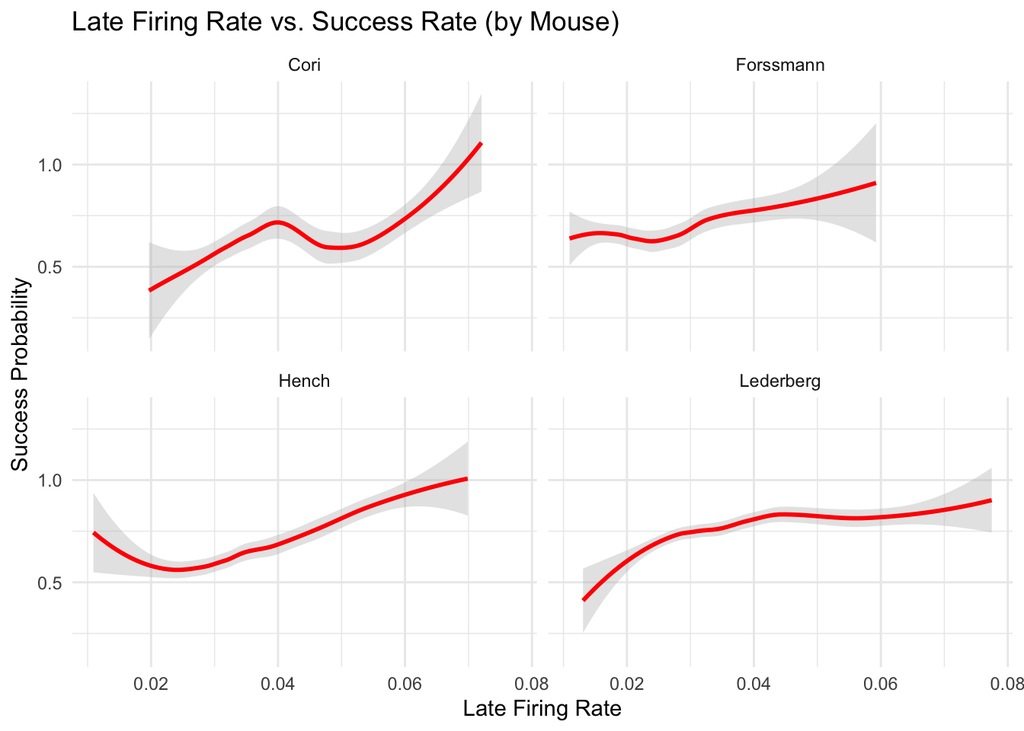

### 1. Early Firing Rate vs. Success Rate:

[output not shown]

### 2. Late Firing Rate vs. Success Rate:

```
The correlation between late firing rate and success probability is more pronounced.
The relationship appears more linear, meaning higher late firing rates consistently lead to better success.
Cori and Hench again show a strong positive relationship, while Forssmann and Lederberg exhibit a more moderate effect.
```

## 4.16 Analyze Session-Wise Correlations: Firing Rate vs. Success Rate, Check if sessions with more high-firing neurons correspond to higher success rates.

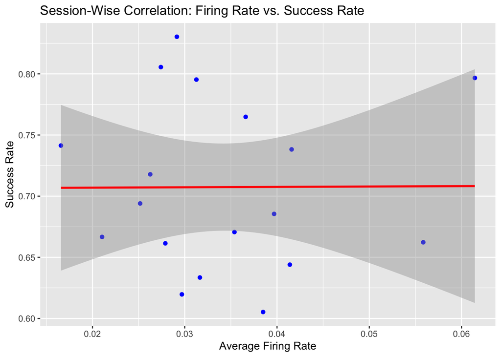

```
## [1] 0.005039317
```

### No Clear Correlation Between Firing Rate and Success Rate

1.The red regression line is nearly flat, indicating that changes in the average firing rate do not significantly affect success rate across sessions.

2.The confidence interval (gray shading) is quite wide, especially at the extremes, suggesting high variability in the relationship.

### Large Variability in Success Rates

1.Some sessions with similar firing rates have very different success rates.

2.A few sessions with relatively high firing rates correspond to both high and low success rates.

## 4.17 Investigating Brain Region Relationship with High Contrast Trials, We will analyze if neurons from specific brain areas have higher firing rates in sessions with more high contrast trials.

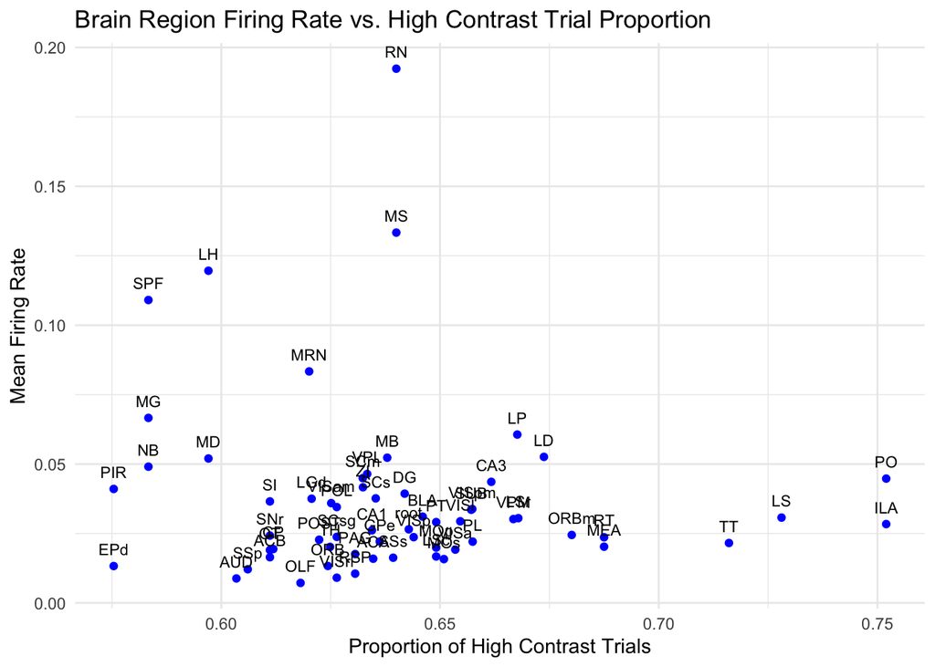

### 1. Certain Brain Regions Show Higher Firing Rates:

```
A few brain regions, such as RN (Red Nucleus), MS (Medial Septum), LH (Lateral Hypothalamus), and SPF (Subparafascicular Area), exhibit significantly higher mean firing rates.
```

This suggests that these regions might be more involved in processing high contrast stimuli or decision-making in response to visual inputs. Most Brain Regions Cluster Around Lower Firing Rates: A majority of brain regions are clustered around a low mean firing rate (~0.02 to 0.05). This indicates that for most regions, firing activity does not significantly increase even when the proportion of high contrast trials is higher.

### 1. Lack of Strong Linear Relationship:

There does not appear to be a strong correlation between high contrast trial proportion and firing rate across brain regions. While some regions with higher contrast exposure do show increased firing rates, others remain relatively stable.

### 2. Variability Across Brain Areas:

Some areas with a similar proportion of high contrast trials have widely different firing rates. This suggests region-specific specialization, meaning some areas are more responsive to contrast variations than others.

[output not shown]

## 4.19 To investigate whether fatigue or adaptation is driving the decrease in neuron activity:Compare Early vs. Late Trials Within Each Session

### 1. If fatigue is present, we expect a gradual decline in neural firing rates in later trials.

### 2. If adaptation is occurring, we might observe consistent firing rates but with changes in which neurons are active.

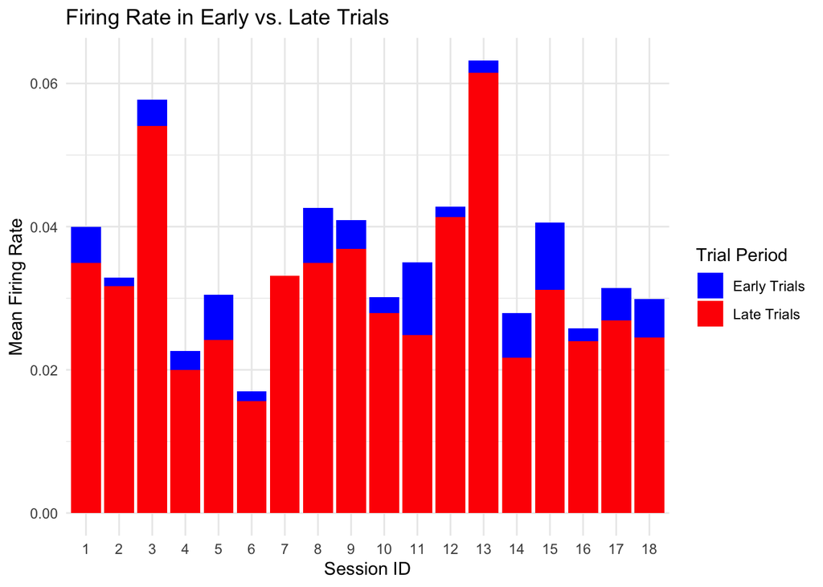

[output not shown]

# 5 Data integration

## 5.1 Integrates multiple session datasets into a single combined dataset

1.Integrates all session data into one structured dataset.

2.Computes important behavioral and neural metrics (contrast difference, firing rates, decision bias).

3.Enables cross-session comparisons by normalizing the data.

4.Prepares the data for further machine learning modeling.

## 5.2 Processes and normalizes the combined dataset

1.Normalizes firing rates to make neural activity comparable across sessions.

2.Tracks cumulative success to measure learning trends per mouse.

3.Saves a cleaned dataset for future modeling and visualization.

4. Computes session-level averages for decision bias, success rate, contrast difference, and firing rates.

## 5.3 Performs Principal Component Analysis (PCA) to reduce the dimensionality of the dataset and integrate session-level and mouse-level trends

```
## [1] "mouse_name"            "session_id"            "avg_bias"
## [4] "avg_success"           "avg_abs_contrast_diff" "avg_early_firing"
## [7] "avg_late_firing"
```

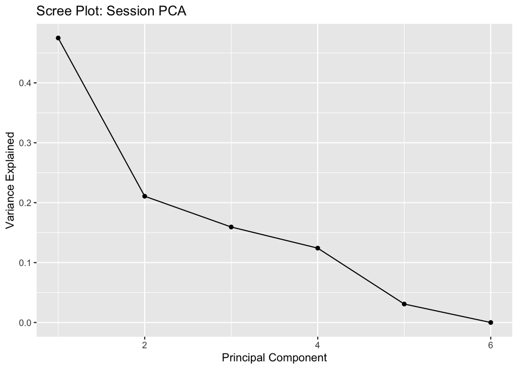

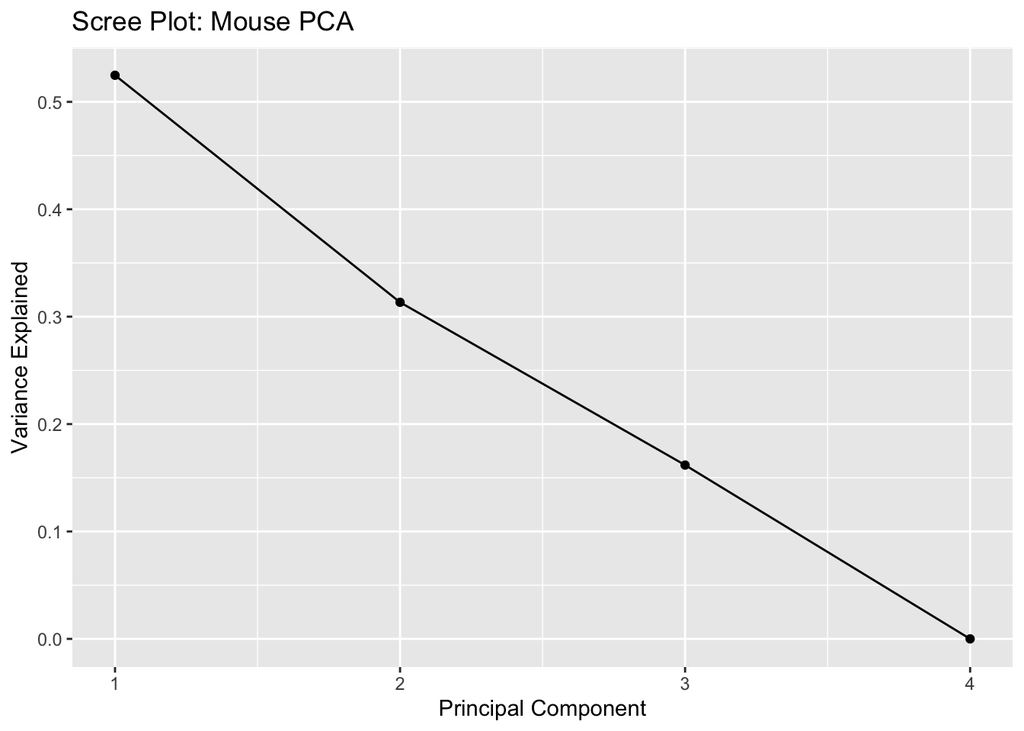

# 6 Predictive modeling

## 6.1 Train-Test Split (Sessions 2-17 for Training, 1 & 18 for Testing), USe XGBoost Model

```
## tibble [5,081 × 19] (S3: tbl_df/tbl/data.frame)
##  $ mouse_name        : chr [1:5081] "Cori" "Cori" "Cori" "Cori" ...
##  $ session_id        : num [1:5081] 1 1 1 1 1 1 1 1 1 1 ...
##  $ contrast_left     : num [1:5081] 0 0 0.5 0 0 0 1 0.5 0 0.5 ...
##  $ contrast_right    : num [1:5081] 0.5 0 1 0 0 0 0.5 0 0 0.25 ...
##  $ abs_contrast_diff : num [1:5081] 0.5 0 0.5 0 0 0 0.5 0.5 0 0.25 ...
##  $ success           : num [1:5081] 1 1 0 0 0 1 1 1 1 1 ...
##  $ early_firing_rate : num [1:5081] 0.0319 0.0296 0.0451 0.0396 0.0367 ...
##  $ late_firing_rate  : num [1:5081] 0.0472 0.036 0.0471 0.0294 0.0345 ...
##  $ decision_bias     : num [1:5081] 0.211 0.211 0.211 0.211 0.211 ...
##  $ left_choice_rate  : num [1:5081] 0.605 0.605 0.605 0.605 0.605 ...
##  $ right_choice_rate : num [1:5081] 0.395 0.395 0.395 0.395 0.395 ...
##  $ norm_early_firing : num [1:5081] -0.7851 -1.1452 1.3317 0.4588 -0.0104 ...
##  $ norm_late_firing  : num [1:5081] 0.746 -0.451 0.739 -1.147 -0.603 ...
##  $ cumulative_success: num [1:5081] 1 1 0.667 0.5 0.4 ...
##  $ PC1.x             : num [1:5081] -2.54 -2.54 -2.54 -2.54 -2.54 ...
##  $ PC2.x             : num [1:5081] 0.0901 0.0901 0.0901 0.0901 0.0901 ...
##  $ PC3               : num [1:5081] -0.0317 -0.0317 -0.0317 -0.0317 -0.0317 ...
##  $ PC1.y             : num [1:5081] 2.1 2.1 2.1 2.1 2.1 ...
##  $ PC2.y             : num [1:5081] 0.447 0.447 0.447 0.447 0.447 ...
```

[output not shown]

```
## [1] TRUE
```

### 1. Findings from Data Analysis

```
Decision success depends on contrast differences:
Large contrast differences → higher success rates.
Small contrast differences → mice struggle more.
Neural activity trends suggest late-stage firing rates play a key role in decision-making.
PCA transformation has been applied, simplifying the dataset while retaining important features.
```

# 7 Prediction performance on the test sets

## 7.1 Evaluate Model on Test Data (Sessions 1 & 18)

```
## XGBoost Model Accuracy on Sessions 1 & 18: 0.7969697
```

```
##          Actual
## Predicted   0   1
##         0  32  12
##         1  55 231
```

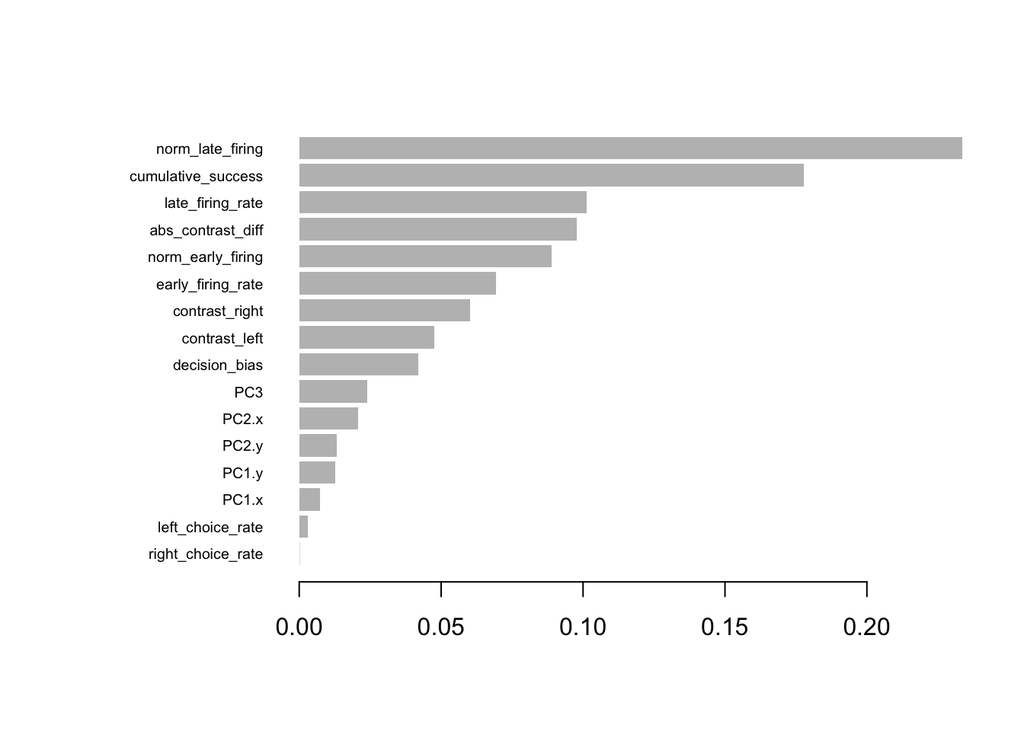

### 1. Model Accuracy on Sessions 1 & 18

```
XGBoost Model Accuracy: 0.7969 (~79.7%)
Decent accuracy (~80%) suggests the model can predict success reasonably well.
Some misclassifications indicate possible areas for improvement.
```

# 8 Discussion

## 1. Confusion Matrix Analysis

```
     Actual
```

Predicted 0 1 0 32 12 1 55 231 True Positives (231): Correctly predicted successful trials. True Negatives (32): Correctly predicted unsuccessful trials. False Positives (55): Model predicted success, but the trial actually failed. False Negatives (12): Model predicted failure, but the trial actually succeeded. High False Positive Rate (55 cases)

## 2. Feature Importance Analysis

[output not shown]

This suggests that the final phase of neuronal activity plays a critical role in decision-making. 2.1 Cumulative_success is also highly significant This means past success strongly influences future trial outcomes. 3.1 Abs_contrast_diff (absolute contrast difference) is a key factor Larger contrast differences increase success rates, confirming that higher visual contrast simplifies decision-making. 4.1 Learly_firing_rate is less important than late firing Suggests that early-stage neural activity is less predictive of success. 5.1 Contrast_left and contrast_right have relatively lower importance This may indicate that contrast effects are already captured through abs_contrast_diff.